# Regression Trees

Lucy D’Agostino McGowan

```r
library(tidymodels)
library(ISLR)
library(rpart.plot)
```

Using the `College` data from the `ISLR` package, predict the number of applications received from a subset of the variables of your choice using a decision tree. (Not sure about the variables? Run `?College` in the console after loading the `ISLR` package)

```r
college_split <- initial_split(College, prop = 0.5)
college_train <- training(college_split)
college_cv <- vfold_cv(college_train, v = 5)
```

To predict the number of applications, I am fitting a *Regression Tree*. I will set the maximum tree depth to 30 and tune based on the cost complexity ($\alpha$)

```r
model_spec <- decision_tree(
  mode = "regression",
  cost_complexity = tune(),
  tree_depth = 30
) %>%
  set_engine("rpart")
```

When choosing your model, be sure you are picking sensible predictors. For example, should you be using the number of applications accepted to predict the number of applications recieved? That doesn’t make much sense!

```r
grid <- expand_grid(cost_complexity = seq(0, 0.1, by = .01))
model <- tune_grid(
  model_spec,
  Apps ~ Private + F.Undergrad + Outstate + Room.Board + Books + Personal + PhD + S.F.Ratio + perc.alumni + Expend + Grad.Rate,
  grid = grid,
  resamples = college_cv
)
```

```r
alpha <- model %>%
  select_best(metric = "rmse") %>%
  pull()
```

It looks like the best model has an $\alpha$ value of 0, meaning the full tree does best.

```r
final_spec <- decision_tree(
  mode = "regression",
  cost_complexity = alpha,
  tree_depth = 30
) %>%
  set_engine("rpart")

final_model <- fit(
  final_spec,
  Apps ~ Private + F.Undergrad + Outstate + Room.Board + Books + Personal + PhD + S.F.Ratio + perc.alumni + Expend + Grad.Rate,
  data = college_train
)
```

```r
college_test <- testing(college_split)
final_model %>%
  predict(new_data = college_test) %>%
  bind_cols(college_test) %>%
  metrics(truth = Apps, estimate = .pred)
```

```
## # A tibble: 3 x 3
##   .metric .estimator .estimate
##   <chr>   <chr>          <dbl>
## 1 rmse    standard    2373.
## 2 rsq     standard       0.667
## 3 mae     standard    1110.
```

We can plot our final tree using `rpart.plot`.

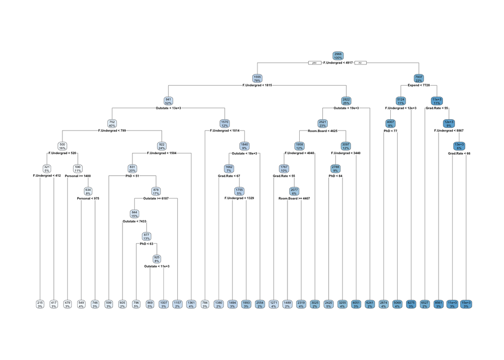

```r
rpart.plot(final_model$fit, roundint = FALSE)
```